# Detección de anomalías con LOF en R

# 1. Introducción

- Una **anomalía** es un caso que se aparta mucho del patrón general (un *outlier*).
- En economía y políticas públicas, detectar lo “raro” es muy valioso: **transacciones fraudulentas**, **contratos públicos atípicos** (posible corrupción), evasión, fallas o errores en los datos.
- Suele ser un problema **no supervisado**: no tenemos ejemplos etiquetados de “fraude”.
- Usaremos el método **LOF** (*Local Outlier Factor*), que marca como anómalos los puntos que están en zonas **menos densas** que sus vecinos.

# 2. Datos

- Trabajaremos con un conjunto (ilustrativo, en 2 dimensiones) de **operaciones financieras**, descritas por dos características: el **monto** (estandarizado) y la **frecuencia** de operaciones del cliente.
- La mayoría de las operaciones forma grupos densos (perfiles “normales”); algunas quedan dispersas y son sospechosas.

```r
trans <- read.csv("data/anomalias.csv")
str(trans)
```

```
## 'data.frame':    292 obs. of  2 variables:
##  $ monto     : num  0.685 -0.282 0.182 0.316 0.202 ...
##  $ frecuencia: num  -0.043 -0.444 -0.222 -0.015 -0.207 0.557 -0.24 -0.217 0.348 -0.528 ...
```

- Veámoslas. A simple vista, ¿cuáles parecen atípicas?

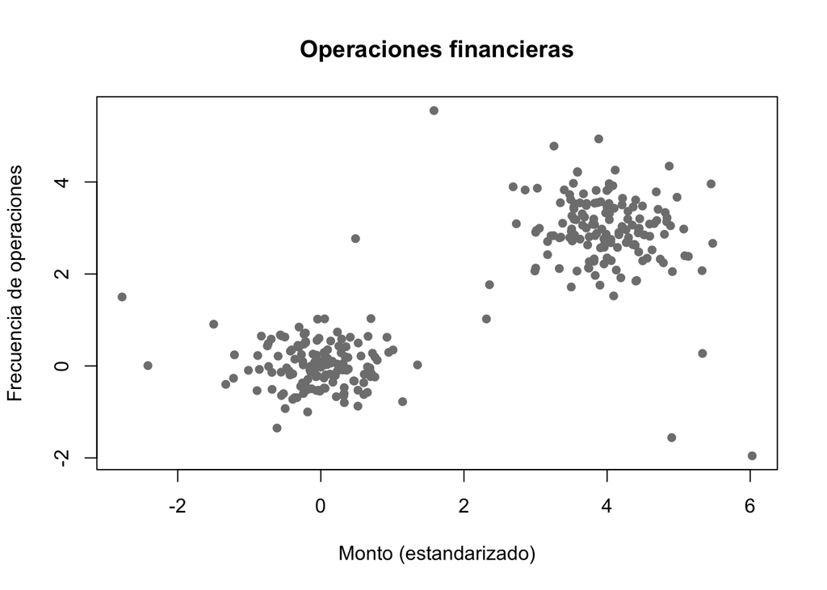

```r
plot(trans$monto, trans$frecuencia, pch = 16, col = "grey50",
     xlab = "Monto (estandarizado)", ylab = "Frecuencia de operaciones",
     main = "Operaciones financieras")
```

# 3. Calcular el LOF

- Usaremos la función `lof()` del paquete `dbscan`. Si no lo tienes instalado:

```r
install.packages("dbscan")
```

```r
library(dbscan)
```

- LOF se basa en **distancias**, así que conviene estandarizar las variables. El parámetro `minPts` indica cuántos vecinos se usan para estimar la densidad local (un valor común es 10–20):

```r
scores <- lof(scale(trans), minPts = 20)
summary(scores)
```

```
##    Min. 1st Qu.  Median    Mean 3rd Qu.    Max.
##  0.9555  0.9973  1.0645  1.2126  1.1813  6.1973
```

- `lof()` devuelve un puntaje por operación: cercano a 1 significa densidad parecida a la de sus vecinas (normal); mucho mayor que 1 indica una operación aislada (sospechosa).

# 4. Identificar las operaciones sospechosas

- Fijemos un umbral (aquí, `LOF > 1.5`) para marcar los casos atípicos:

```r
trans$lof <- scores
trans$atipica <- scores > 1.5
table(trans$atipica)
```

```
##
## FALSE  TRUE
##   267    25
```

- Visualicemos el resultado: tamaño proporcional al puntaje LOF y en rojo las marcadas como atípicas (posible fraude):

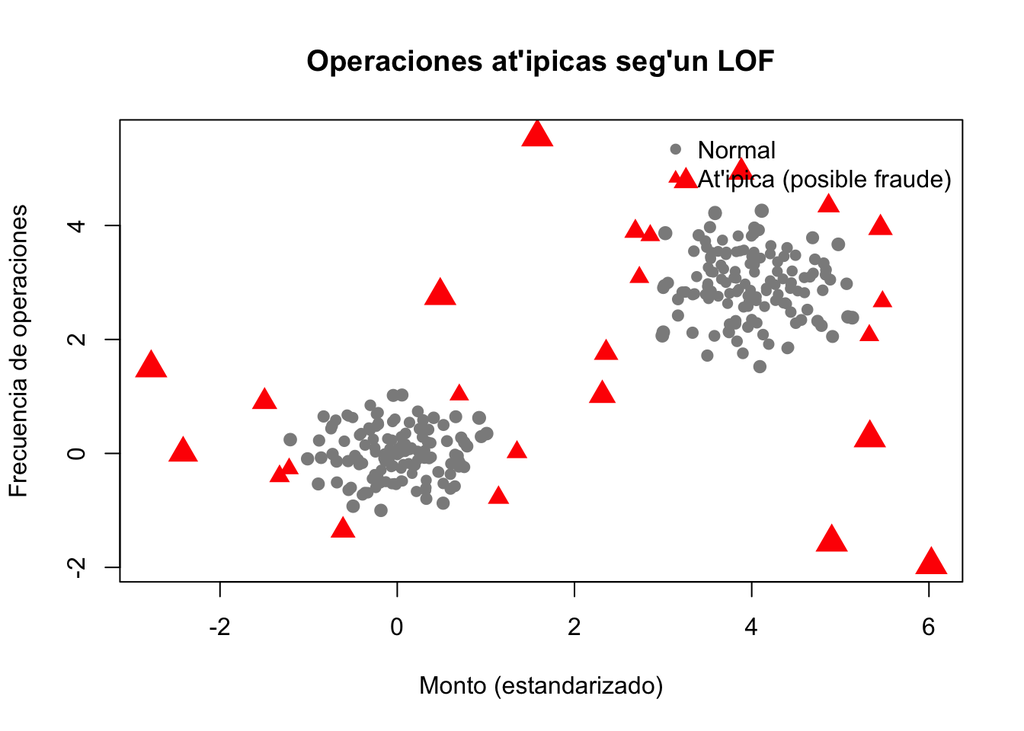

```r
plot(trans$monto, trans$frecuencia,
     cex = pmin(trans$lof, 3) * 0.6 + 0.4,
     pch = ifelse(trans$atipica, 17, 16),
     col = ifelse(trans$atipica, "red", "grey55"),
     xlab = "Monto (estandarizado)", ylab = "Frecuencia de operaciones",
     main = "Operaciones atípicas según LOF")
legend("topright", c("Normal", "Atípica (posible fraude)"), pch = c(16, 17),
       col = c("grey55", "red"), bty = "n")
```

- Veamos las operaciones con mayor puntaje (las más sospechosas, que un analista revisaría primero):

```r
head(trans[order(-trans$lof), ], 5)
```

```
##      monto frecuencia      lof atipica
## 286  4.903     -1.558 6.197328    TRUE
## 282  6.027     -1.954 5.963856    TRUE
## 290  1.581      5.553 4.413186    TRUE
## 291 -2.777      1.500 4.097961    TRUE
## 284  0.485      2.769 3.735800    TRUE
```

# 5. Para cerrar

- **No hay un umbral universal**: hay que decidir cuántos casos marcar, según el contexto (¿qué cuesta más, dejar pasar un fraude o investigar una operación legítima?).
- LOF detecta anomalías **locales** (relativas a su vecindario), no solo las globales.
- Como se basa en distancias, **estandarizar** las variables es importante.
- La misma técnica sirve para señalar **contratos públicos atípicos** que ameritan auditoría, lecturas anómalas de sensores, o errores de captura en una base.
- Como ejercicio: cambia `minPts` (por ejemplo a 5 o a 50) y el umbral, y observa cómo cambian las operaciones detectadas.